# Replication of Experiment 1 by Child, Oakhill, & Garnham (2018, Language, Cognition and Neuroscience)

### Results of control measures

There were three exclusion criteria used. Firstly, participants (*n* = 2 participants) who had reading times of less then 400ms for more than half the trials were excluded from analysis. Secondly, reading times that were longer than 15 seconds were re-coded as missing data (*n* = 155 data points across 52 participants; 1.23% of datapoints). Finally, outliers 2.5 standard deviations below or above the mean reading times per sentence per participant were removed (*n* = 388 data points; 3.07% of datapoints). Thus, a total of 98 participants (4.30% missing reading time data) were retained for analysis.

### Confirmatory analysis

The basic descriptive statistics of the sample (age, years of formal education, emotion rating responses, average raw reading times) are presented below.

```r
### participant level statistics of the sample

psych::describe(filtered_data %>%
                  dplyr::mutate(
                    ReadingTime = rowMeans(as.matrix(filtered_data %>% dplyr::select(ends_with('RT'))), na.rm = TRUE),
                    EmotionRating = rowMeans(as.matrix(filtered_data %>% dplyr::select(ends_with('ER'))), na.rm = TRUE)) %>%
                  dplyr::select(Age, Education, ReadingTime, EmotionRating))
```

```
              vars  n  mean    sd median trimmed   mad   min   max range  skew
Age              1 98 39.52 12.71  38.00   38.96 16.31 18.00 76.00 58.00  0.39
Education        2 98 15.04  3.97  16.00   15.21  2.97  2.00 24.00 22.00 -0.63
ReadingTime      3 98  1.90  0.81   1.77    1.82  0.59  0.67  4.91  4.24  1.26
EmotionRating    4 98  5.49  0.74   5.40    5.42  0.49  3.88  8.21  4.33  1.20
              kurtosis   se
Age              -0.46 1.28
Education         0.95 0.40
ReadingTime       1.99 0.08
EmotionRating     2.77 0.07
```

```r
long_RT_data %>%
  group_by(Perspective, Valence) %>%
  summarise(Mean_RT = mean(RT, na.rm=T),
            StdDev_RT = sd(RT, na.rm=T))
```

```
# A tibble: 4 × 4
# Groups:   Perspective [2]
  Perspective Valence Mean_RT StdDev_RT
  <fct>       <fct>     <dbl>     <dbl>
1 FALSE       FALSE      1.89      1.44
2 FALSE       TRUE       1.93      1.40
3 TRUE        FALSE      1.84      1.36
4 TRUE        TRUE       1.93      1.40
```

```r
long_ER_data %>%
  group_by(Perspective, Valence) %>%
  summarise(Mean_ER = mean(ER, na.rm=T),
            StdDev_ER = sd(ER, na.rm=T))
```

```
# A tibble: 4 × 4
# Groups:   Perspective [2]
  Perspective Valence Mean_ER StdDev_ER
  <fct>       <fct>     <dbl>     <dbl>
1 FALSE       FALSE      3.65      1.74
2 FALSE       TRUE       7.08      1.96
3 TRUE        FALSE      3.50      1.64
4 TRUE        TRUE       7.40      1.82
```

In line with the original study and the replication study done by Bunderson, log-residual reading times were calculated to account for the length effects of different items. Initially, a regression of (log-transformed) reading times against the number of characters per sentence was performed in line with the original study and with Bunderson’s replication. However, the model failed to converge. Thus, a regression of (log-transformed) reading times against the scaled value of the number of characters per sentence was performed and the log-residual reading times (with an intercept of zero for each participant) were used for the main analyses later on.

```r
### Regress log RT against character count and create variable
reg_RT_data = lmer(log_RT ~ 1 + Character_Count_scaled + (1 + Character_Count_scaled | Subject), long_RT_data)
long_RT_data$log_RT_Resid <- residuals(reg_RT_data)
rm(reg_RT_data)
```

```r
### Regress log RT against character count and create variable (sensitivity)
reg_RT_data_sensitivity = lmer(log_RT ~ 1 + Character_Count_scaled + (1 + Character_Count_scaled | Subject), long_RT_data_sensitivity)
long_RT_data_sensitivity$log_RT_Resid <- residuals(reg_RT_data_sensitivity)
rm(reg_RT_data_sensitivity)
```

In line with the original study, a LME model was run whereby random intercepts for both participants and items were included in the model. Results show that there was no interaction between valence and perspective on log residual reading times.

```r
### analyses: LME and contrasts
 RT_model <-
  lmer(log_RT_Resid ~ Perspective + Valence + Perspective*Valence +
         (1 | Subject) + (1 | Passage),
       data = long_RT_data)
```

```
boundary (singular) fit: see help('isSingular')
```

```r
  summary(RT_model, ddf = "Satterthwaite")
```

```
Linear mixed model fit by REML. t-tests use Satterthwaite's method [
lmerModLmerTest]
Formula: log_RT_Resid ~ Perspective + Valence + Perspective * Valence +
    (1 | Subject) + (1 | Passage)
   Data: long_RT_data

REML criterion at convergence: 19264.7

Scaled residuals:
     Min       1Q   Median       3Q      Max
-10.3644  -0.5029  -0.0365   0.5020   4.9016

Random effects:
 Groups   Name        Variance Std.Dev.
 Passage  (Intercept) 0.02277  0.1509
 Subject  (Intercept) 0.00000  0.0000
 Residual             0.27780  0.5271
Number of obs: 12099, groups:  Passage, 258; Subject, 98

Fixed effects:
                              Estimate Std. Error         df t value Pr(>|t|)
(Intercept)                   0.013436   0.021511 250.870491   0.625    0.533
PerspectiveTRUE              -0.020954   0.030421 250.861987  -0.689    0.492
ValenceTRUE                  -0.009943   0.029861 251.270792  -0.333    0.739
PerspectiveTRUE:ValenceTRUE   0.019468   0.042228 251.234628   0.461    0.645

Correlation of Fixed Effects:
            (Intr) PrTRUE VlTRUE
PrspctvTRUE -0.707
ValenceTRUE -0.720  0.509
PTRUE:VTRUE  0.509 -0.720 -0.707
optimizer (nloptwrap) convergence code: 0 (OK)
boundary (singular) fit: see help('isSingular')
```

```r
### analyses: LME and contrasts for sensitivity analyses
 RT_model_sensitivity <-
  lmer(log_RT_Resid ~ Perspective + Valence + Perspective*Valence +
         (1 | Subject) + (1 | Passage),
       data = long_RT_data_sensitivity)
```

```
boundary (singular) fit: see help('isSingular')
```

```r
  summary(RT_model_sensitivity, ddf = "Satterthwaite")
```

```
Linear mixed model fit by REML. t-tests use Satterthwaite's method [
lmerModLmerTest]
Formula: log_RT_Resid ~ Perspective + Valence + Perspective * Valence +
    (1 | Subject) + (1 | Passage)
   Data: long_RT_data_sensitivity

REML criterion at convergence: 22542.6

Scaled residuals:
    Min      1Q  Median      3Q     Max
-9.3252 -0.5005 -0.0519  0.4514  6.5386

Random effects:
 Groups   Name        Variance  Std.Dev.
 Passage  (Intercept) 2.763e-02 1.662e-01
 Subject  (Intercept) 2.706e-16 1.645e-08
 Residual             3.410e-01 5.840e-01
Number of obs: 12549, groups:  Passage, 258; Subject, 100

Fixed effects:
                              Estimate Std. Error         df t value Pr(>|t|)
(Intercept)                   0.005020   0.023637 251.829694   0.212    0.832
PerspectiveTRUE              -0.012862   0.033419 251.593435  -0.385    0.701
ValenceTRUE                   0.002571   0.032807 252.106143   0.078    0.938
PerspectiveTRUE:ValenceTRUE   0.009012   0.046385 251.878700   0.194    0.846

Correlation of Fixed Effects:
            (Intr) PrTRUE VlTRUE
PrspctvTRUE -0.707
ValenceTRUE -0.720  0.510
PTRUE:VTRUE  0.510 -0.720 -0.707
optimizer (nloptwrap) convergence code: 0 (OK)
boundary (singular) fit: see help('isSingular')
```

To test if participants read positively-valenced passages faster when they were written from a personal (second person’s) perspective compared to when they were written from an onlooker’s (third person’s) perspective, pairwise comparisons were conducted using the *lsmeans* package, as in the original study. Results show that there was no significant difference in log residual reading times between the perspective conditions within the positive valence condition. The graph of the results are presented below. alongside the graph of the results obtained by the previous replication study and the results obtained by the original study.

```r
### lsmeans to text for pairwise contrasts
  RT_model_con <-
    lsmeans(RT_model,
            pairwise ~ Perspective | Valence,
            at = list(Perspective = c("TRUE", "FALSE"), Valence = c("TRUE", "FALSE")))
```

```
Note: D.f. calculations have been disabled because the number of observations exceeds 3000.
To enable adjustments, add the argument 'pbkrtest.limit = 12099' (or larger)
[or, globally, 'set emm_options(pbkrtest.limit = 12099)' or larger];
but be warned that this may result in large computation time and memory use.
```

```
Note: D.f. calculations have been disabled because the number of observations exceeds 3000.
To enable adjustments, add the argument 'lmerTest.limit = 12099' (or larger)
[or, globally, 'set emm_options(lmerTest.limit = 12099)' or larger];
but be warned that this may result in large computation time and memory use.
```

```r
  contrast(RT_model_con, method = "pairwise", ddf = "Satterthwaite")
```

```
Valence = TRUE:
 contrast     estimate     SE  df z.ratio p.value
 TRUE - FALSE -0.00149 0.0293 Inf  -0.051  0.9595

Valence = FALSE:
 contrast     estimate     SE  df z.ratio p.value
 TRUE - FALSE -0.02095 0.0304 Inf  -0.689  0.4910

Degrees-of-freedom method: asymptotic
```

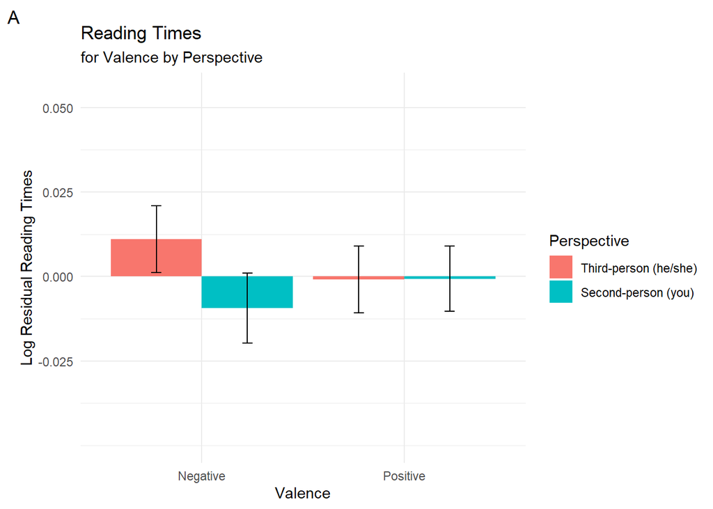

```r
# graph RT results for current rescue study
  RT_data_graph = long_RT_data %>%
    group_by(Perspective, Valence) %>%
    summarise(Mean_logRTResid = mean(log_RT_Resid, na.rm = TRUE),
              SE_RT = sd(log_RT_Resid, na.rm = TRUE) / sqrt( length(log_RT_Resid[!is.na(log_RT_Resid)])))
ggplot(data = RT_data_graph,
       aes(x = Valence,
           y = Mean_logRTResid,
           fill = Perspective)) +
  geom_bar(position = "dodge",
           stat = "identity") +
  geom_errorbar(aes(ymin = Mean_logRTResid - SE_RT,
                    ymax = Mean_logRTResid + SE_RT),
                width = .1, position=position_dodge(.9),
                na.rm = TRUE)  +
  labs(title = "Reading Times ",
       subtitle = "for Valence by Perspective",
       tag = "A",
       y = "Log Residual Reading Times",
       x = "Valence") +
  scale_x_discrete(labels=c("FALSE"="Negative",
                            "TRUE"="Positive")) +
  scale_fill_discrete(name="Perspective",
                      labels = c("Third-person (he/she)",
                                 "Second-person (you)")) +
  coord_cartesian(ylim = c(-0.050, 0.055)) +
  scale_y_continuous(breaks = c(-0.025, 0, 0.025, 0.050)) +
  theme_minimal()
```

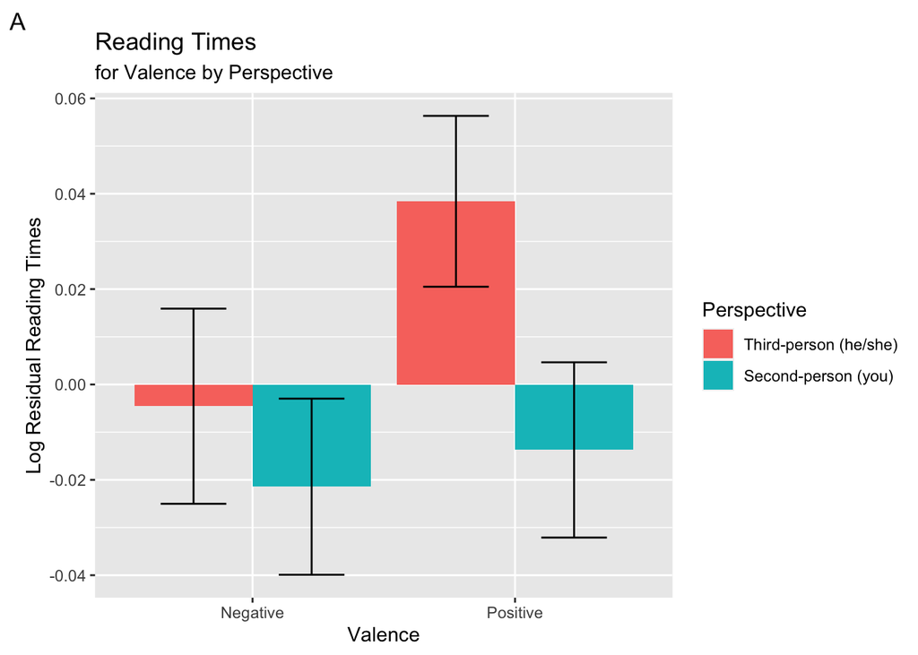

```r
  # graph RT results for original replication study (Bunderson, 2020)
  knitr::include_graphics("https://github.com/psych251/child2018_rescue/blob/main/writeup/bunderson2020_RTfigure.png?raw=TRUE")
```

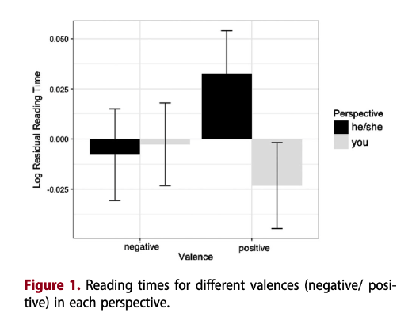

```r
  # graph RT results for original study (Child et al., 2018)
  knitr::include_graphics("https://raw.githubusercontent.com/psych251/child2018_rescue/main/original_paper/child2018_figure1.png?raw=TRUE")
```

```r
  # clean environment
  rm(RT_model, RT_model_con, RT_data_graph)
```

```r
### lsmeans to text for pairwise contrasts for sensitivity analyses
  RT_model_con_sensitivity <-
    lsmeans(RT_model_sensitivity,
            pairwise ~ Perspective | Valence,
            at = list(Perspective = c("TRUE", "FALSE"), Valence = c("TRUE", "FALSE")))
```

```
Note: D.f. calculations have been disabled because the number of observations exceeds 3000.
To enable adjustments, add the argument 'pbkrtest.limit = 12549' (or larger)
[or, globally, 'set emm_options(pbkrtest.limit = 12549)' or larger];
but be warned that this may result in large computation time and memory use.
```

```
Note: D.f. calculations have been disabled because the number of observations exceeds 3000.
To enable adjustments, add the argument 'lmerTest.limit = 12549' (or larger)
[or, globally, 'set emm_options(lmerTest.limit = 12549)' or larger];
but be warned that this may result in large computation time and memory use.
```

```r
  contrast(RT_model_con_sensitivity, method = "pairwise", ddf = "Satterthwaite")
```

```
Valence = TRUE:
 contrast     estimate     SE  df z.ratio p.value
 TRUE - FALSE -0.00385 0.0322 Inf  -0.120  0.9047

Valence = FALSE:
 contrast     estimate     SE  df z.ratio p.value
 TRUE - FALSE -0.01286 0.0334 Inf  -0.385  0.7003

Degrees-of-freedom method: asymptotic
```

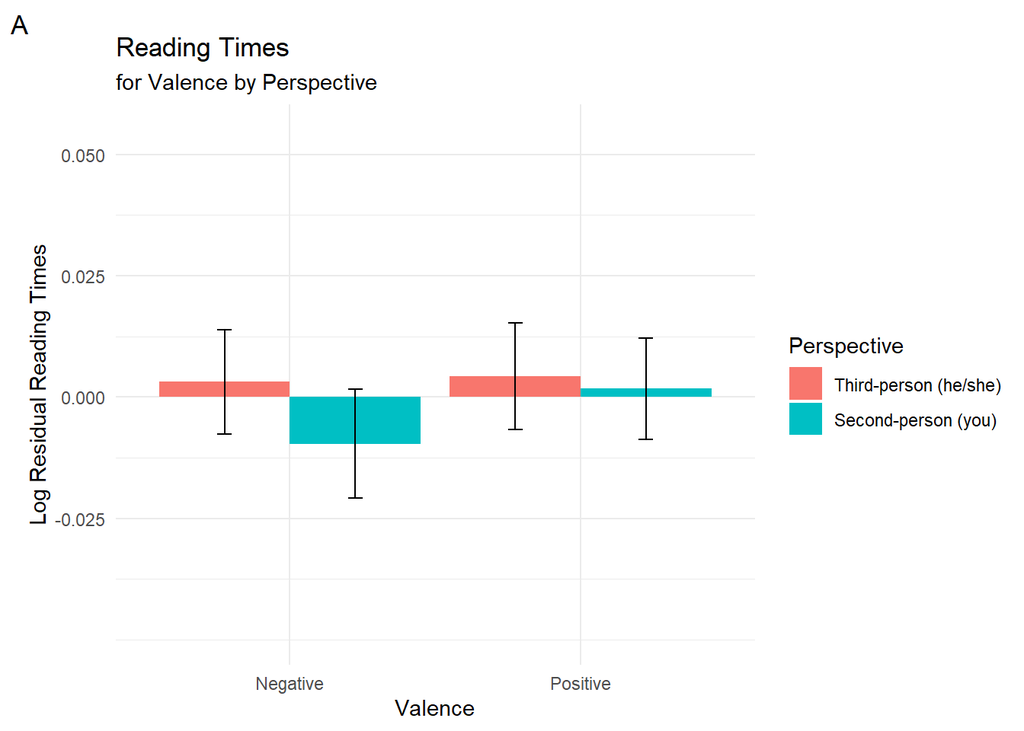

```r
# graph RT results for current rescue study (Sensitivity)
  RT_data_graph_sensitivity = long_RT_data_sensitivity %>%
    group_by(Perspective, Valence) %>%
    summarise(Mean_logRTResid = mean(log_RT_Resid, na.rm = TRUE),
              SE_RT = sd(log_RT_Resid, na.rm = TRUE) / sqrt( length(log_RT_Resid[!is.na(log_RT_Resid)])))
ggplot(data = RT_data_graph_sensitivity,
       aes(x = Valence,
           y = Mean_logRTResid,
           fill = Perspective)) +
  geom_bar(position = "dodge",
           stat = "identity") +
  geom_errorbar(aes(ymin = Mean_logRTResid - SE_RT,
                    ymax = Mean_logRTResid + SE_RT),
                width = .1, position=position_dodge(.9),
                na.rm = TRUE)  +
  labs(title = "Reading Times ",
       subtitle = "for Valence by Perspective",
       tag = "A",
       y = "Log Residual Reading Times",
       x = "Valence") +
  scale_x_discrete(labels=c("FALSE"="Negative",
                            "TRUE"="Positive")) +
  scale_fill_discrete(name="Perspective",
                      labels = c("Third-person (he/she)",
                                 "Second-person (you)")) +
  coord_cartesian(ylim = c(-0.050, 0.055)) +
  scale_y_continuous(breaks = c(-0.025, 0, 0.025, 0.050)) +
  theme_minimal()
```

### Exploratory analyses

To explore if educational status moderated the relationship between perspective of the passage and reading time among positively-valenced passages, a LME was conducted and an interaction term between the years of formal education and perspective was included as a predictor variable in the model. Results show that there was no three-way interaction between education, valence and perspective on log residual reading times.

The graphical results are presented below. Based on simple slope analyses, the only marginally significant (p = .05) simple slope of education was when valence was positive and perspective was third-person. Specifically, individuals with more years of formal education appear to process third-person positive passages quicker than individuals with less years of formal education.

```r
### analyses: education as moderator
 RT_model <-
  lmer(log_RT_Resid ~ Perspective + Valence + Perspective*Valence*Education +
         (1 | Subject) + (1 | Passage),
       data = long_RT_data)
```

```
boundary (singular) fit: see help('isSingular')
```

```r
  summary(RT_model, ddf = "Satterthwaite")
```

```
Linear mixed model fit by REML. t-tests use Satterthwaite's method [
lmerModLmerTest]
Formula: log_RT_Resid ~ Perspective + Valence + Perspective * Valence *
    Education + (1 | Subject) + (1 | Passage)
   Data: long_RT_data

REML criterion at convergence: 19298.7

Scaled residuals:
     Min       1Q   Median       3Q      Max
-10.3695  -0.5017  -0.0361   0.5056   4.8770

Random effects:
 Groups   Name        Variance Std.Dev.
 Passage  (Intercept) 0.02277  0.1509
 Subject  (Intercept) 0.00000  0.0000
 Residual             0.27773  0.5270
Number of obs: 12099, groups:  Passage, 258; Subject, 98

Fixed effects:
                                        Estimate Std. Error         df t value
(Intercept)                           -4.334e-02  4.369e-02  3.479e+03  -0.992
PerspectiveTRUE                        1.077e-02  6.128e-02  3.393e+03   0.176
ValenceTRUE                            1.177e-01  6.047e-02  3.468e+03   1.947
Education                              3.767e-03  2.523e-03  1.192e+04   1.493
PerspectiveTRUE:ValenceTRUE           -6.357e-02  8.497e-02  3.397e+03  -0.748
PerspectiveTRUE:Education             -2.098e-03  3.536e-03  1.192e+04  -0.593
ValenceTRUE:Education                 -8.466e-03  3.486e-03  1.190e+04  -2.428
PerspectiveTRUE:ValenceTRUE:Education  5.491e-03  4.900e-03  1.190e+04   1.121
                                      Pr(>|t|)
(Intercept)                             0.3213
PerspectiveTRUE                         0.8605
ValenceTRUE                             0.0516 .
Education                               0.1355
PerspectiveTRUE:ValenceTRUE             0.4544
PerspectiveTRUE:Education               0.5530
ValenceTRUE:Education                   0.0152 *
PerspectiveTRUE:ValenceTRUE:Education   0.2625
---
Signif. codes:  0 '***' 0.001 '**' 0.01 '*' 0.05 '.' 0.1 ' ' 1

Correlation of Fixed Effects:
             (Intr) PrTRUE VlTRUE Eductn PrTRUE:VTRUE PTRUE:E VTRUE:
PrspctvTRUE  -0.713
ValenceTRUE  -0.723  0.515
Education    -0.870  0.621  0.629
PrTRUE:VTRUE  0.514 -0.721 -0.712 -0.448
PrspcTRUE:E   0.621 -0.868 -0.449 -0.713  0.626
VlncTRUE:Ed   0.630 -0.449 -0.870 -0.724  0.619        0.516
PTRUE:VTRUE: -0.448  0.626  0.619  0.515 -0.868       -0.722  -0.711
optimizer (nloptwrap) convergence code: 0 (OK)
boundary (singular) fit: see help('isSingular')
```

[output not shown]

```
█████████████████████ While Valence (2nd moderator) = FALSE ████████████████████

SIMPLE SLOPES ANALYSIS

Slope of Education when Perspective = FALSE:

  Est.   S.E.   t val.      p
------ ------ -------- ------
  0.00   0.00     1.49   0.14

Slope of Education when Perspective = TRUE:

  Est.   S.E.   t val.      p
------ ------ -------- ------
  0.00   0.00     0.67   0.50

█████████████████████ While Valence (2nd moderator) = TRUE █████████████████████

SIMPLE SLOPES ANALYSIS

Slope of Education when Perspective = FALSE:

   Est.   S.E.   t val.      p
------- ------ -------- ------
  -0.00   0.00    -1.95   0.05

Slope of Education when Perspective = TRUE:

   Est.   S.E.   t val.      p
------- ------ -------- ------
  -0.00   0.00    -0.55   0.59
```

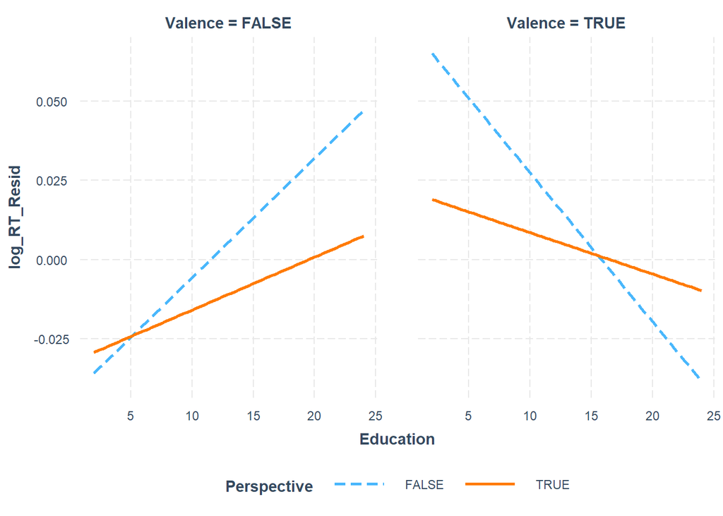

```r
interactions::probe_interaction(RT_model,
                                Education,
                                Perspective,
                                Valence,
                                centered = "none")
```

### Emotion rating

Although not the focus of the current rescue replication study, a separate linear mixed effects (LME) model was run to analyze the emotion ratings for each of the four types of passages. Perspective and valence were incorporated as fixed effects, while participants and items were treated as random intercepts. In the original study, Child et al. found “an interaction between perspective and valence for self-reported emotions”, whereby “Participants gave similar ratings for both perspectives when they were presented with a negative emotion (“he/she”: M = 3.36, SD = 1.29; “you”: M = 3.30, SD = 1.46; t = 1.08, p > 0.1), but they gave higher ratings for the second person perspective you (M = 7.04, SD = 1.77) than for the third person perspective (M = 6.82, SD = 1.73) when reading about a positive emotion (perspective effect for positive emotion: (t(4335) = 3.67, p < .001, see Figure 2)” (Child et al., 2018, p.883).

However, in the current study, there was no interaction between valence and perspective on emotion ratings. Within the positively valenced passages, there was also no significant effect of perspective on emotional rating. Nonetheless, the trends are in the same direction as those observed in the original study.

```r
### analyses: emotion ratings
 ER_model <-
  lmer(ER ~ Perspective + Valence + Perspective*Valence +
         (1 | Subject) + (1 | Passage),
       data = long_ER_data)
  summary(ER_model, ddf = "Satterthwaite")
```

```
Linear mixed model fit by REML. t-tests use Satterthwaite's method [
lmerModLmerTest]
Formula: ER ~ Perspective + Valence + Perspective * Valence + (1 | Subject) +
    (1 | Passage)
   Data: long_ER_data

REML criterion at convergence: 9065.4

Scaled residuals:
    Min      1Q  Median      3Q     Max
-4.7867 -0.6940 -0.0283  0.7099  3.0509

Random effects:
 Groups   Name        Variance Std.Dev.
 Subject  (Intercept) 0.4320   0.6573
 Passage  (Intercept) 0.3933   0.6272
 Residual             2.4684   1.5711
Number of obs: 2352, groups:  Subject, 98; Passage, 48

Fixed effects:
                            Estimate Std. Error      df t value Pr(>|t|)
(Intercept)                   3.6495     0.2034 54.5263  17.939   <2e-16 ***
PerspectiveTRUE              -0.1306     0.2781 44.0708  -0.469    0.641
ValenceTRUE                   3.4236     0.2667 44.0356  12.839   <2e-16 ***
PerspectiveTRUE:ValenceTRUE   0.4562     0.3853 44.0462   1.184    0.243
---
Signif. codes:  0 '***' 0.001 '**' 0.01 '*' 0.05 '.' 0.1 ' ' 1

Correlation of Fixed Effects:
            (Intr) PrTRUE VlTRUE
PrspctvTRUE -0.654
ValenceTRUE -0.682  0.499
PTRUE:VTRUE  0.472 -0.722 -0.692
```

```r
  ### lsmeans to text for pairwise contrasts
  ER_model_con <-
    lsmeans(ER_model,
            pairwise ~ Perspective | Valence,
            at = list(Perspective = c("TRUE", "FALSE"), Valence = c("TRUE", "FALSE")))
  contrast(ER_model_con, method = "pairwise", ddf = "Satterthwaite")
```

```
Valence = TRUE:
 contrast     estimate    SE   df t.ratio p.value
 TRUE - FALSE    0.326 0.267 43.8   1.221  0.2285

Valence = FALSE:
 contrast     estimate    SE   df t.ratio p.value
 TRUE - FALSE   -0.131 0.278 43.8  -0.469  0.6410

Degrees-of-freedom method: kenward-roger
```

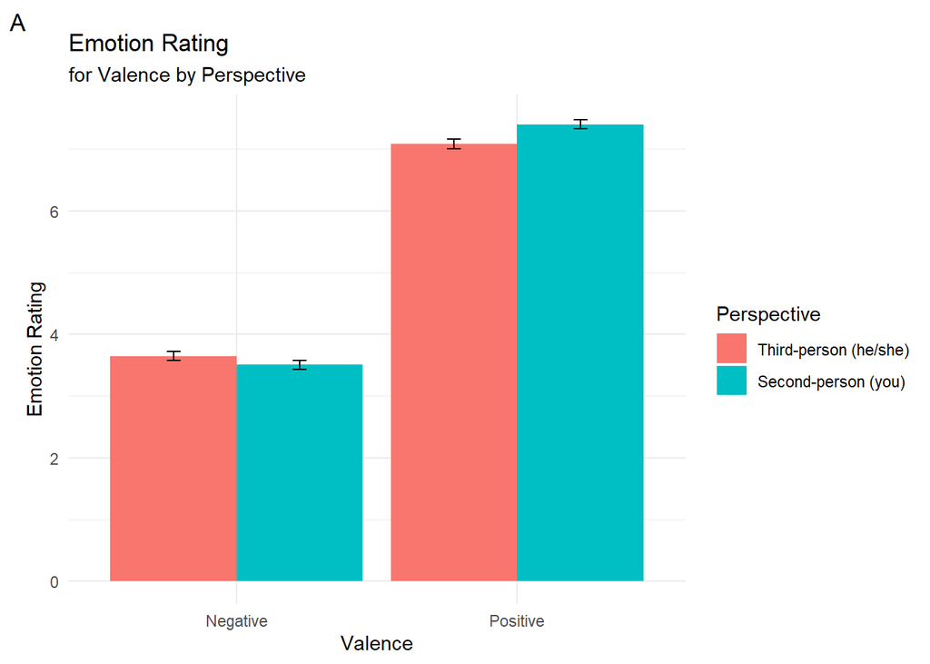

```r
# graph ER results
  ER_data_graph = long_ER_data %>%
    group_by(Perspective, Valence) %>%
    summarise(Mean_ER = mean(ER, na.rm = TRUE),
              SE_ER = sd(ER, na.rm = TRUE) / sqrt( length(ER[!is.na(ER)])))
ggplot(data = ER_data_graph,
       aes(x = Valence,
           y = Mean_ER,
           fill = Perspective)) +
  geom_bar(position = "dodge",
           stat = "identity") +
  geom_errorbar(aes(ymin = Mean_ER - SE_ER,
                    ymax = Mean_ER + SE_ER),
                width = .1, position=position_dodge(.9),
                na.rm = TRUE)  +
  labs(title = "Emotion Rating",
       subtitle = "for Valence by Perspective",
       tag = "A",
       y = "Emotion Rating",
       x = "Valence") +
  scale_x_discrete(labels=c("FALSE"="Negative",
                            "TRUE"="Positive")) +
  scale_fill_discrete(name="Perspective",
                      labels = c("Third-person (he/she)",
                                 "Second-person (you)")) +
  coord_cartesian(ylim = c(0, 7.5)) +
  scale_y_continuous(breaks = c(0, 2, 4, 6)) +
  theme_minimal()
```

## Discussion

Taken together, the current study did not find any significant difference in the reading time of positively-valenced passages. Interestingly, the trends observed (see graphs presented above showing the log residual regression reading times in each of the four conditions) in the first replication study by Bunderson (2020) matched the original findings more closely than the current rescue study, although the p-values obtained by Bunderson were non-significant. To examine the collective evidence for the hypothesis that individuals read quicker when positive stories are presented in the second- rather than third-person perspective, a mini-meta analysis is conducted below with the original, initial replication, and current rescue study.

## Mini meta analysis

The effect of interest was the pairwise t-test examining the log residual reading times of second- and third-person positive passages. Cohen’s d was difficult to calculate given that the model was a mixed effects model and I was not sure whether my method of calculating it was correct. Hence, this analysis should be considered with criticism.

### Effect size from original study (Child et al., 2018)

To get the standard error of the Cohen’s d estimate, the formula “SE_d = (2(1-r)/n + d<sup>2/2n)</sup>0.5” was used, whereby *r* is the correlation of participants’ reading times in the two conditions (positive-personal and positive-onlooker), *n* is the number of participants, and *d* is the Cohen’s d value. *r* is unknown based on the available data, and is assumed to be 0.70 in the current work. Thus, I calculated the SE_d to be: * SE_d = ((2x(1-0.70))/36 + 0.113<sup>2</sup>/(2x36))<sup>0.5</sup> = 0.130.

### Effect size from replication study (Bunderson, 2020)

To get the standard error of the Cohen’s d estimate, the same formula was used as above, and *r* is again assumed to be 0.70. Thus, I calculated the SE_d to be: * SE_d = ((2x(1-0.70))/40 + 0.270<sup>2</sup>/(2x40))<sup>0.5</sup> = 0.126.

### Effect size from current rescue study

To get the standard error of the Cohen’s d estimate, the same formula was used as above, and *r* is again assumed to be 0.70. Thus, I calculated the SE_d to be: * SE_d = ((2x(1-0.70))/98 + 0.169<sup>2</sup>/(2x98))<sup>0.5</sup> = 0.079.

### Mini meta analysis results

Based on the mini meta analysis, there was no significant effect of perspective on reading time among positively-valenced passages. Interestingly, the effect sizes calculated suggest that Bunderson’s (2020) replication may have provided stronger evidence for the hypothesis than the original study. Nonetheless, the above calculations may have been inaccurate, so this analysis should be interpreted with caution.

The mini meta-analysis suggests that the effect size is d = -0.056 (se = 0.135, 95% CI = [-0.32, 0.21], p = .678).

```r
### analysis: mini meta-analysis
  minimeta_dataset <- data.frame(
    study = c("Child et al., 2018", "Bunderson, 2020", "Lua, 2023"),
    N = c(36,40,98),
    cohens_d = c(-0.113,-0.270,0.169),
    se = c(0.130,0.126,0.079))

  mini_meta_mod <- rma(yi = cohens_d, sei = se, slab = study, data = minimeta_dataset)
  summary(mini_meta_mod)
```

```
Random-Effects Model (k = 3; tau^2 estimator: REML)

  logLik  deviance       AIC       BIC      AICc
  0.1164   -0.2329    3.7671    1.1534   15.7671

tau^2 (estimated amount of total heterogeneity): 0.0418 (SE = 0.0545)
tau (square root of estimated tau^2 value):      0.2045
I^2 (total heterogeneity / total variability):   77.53%
H^2 (total variability / sampling variability):  4.45

Test for Heterogeneity:
Q(df = 2) = 9.8832, p-val = 0.0071

Model Results:

estimate      se     zval    pval    ci.lb   ci.ub
 -0.0560  0.1346  -0.4157  0.6776  -0.3198  0.2079

---
Signif. codes:  0 '***' 0.001 '**' 0.01 '*' 0.05 '.' 0.1 ' ' 1
```

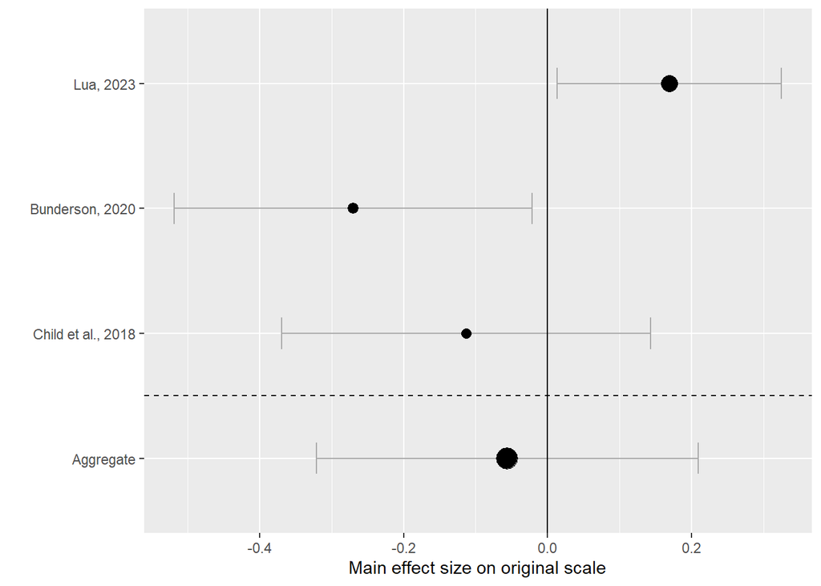

```r
# plot forest plot
  aggregate <- tibble(study = "Aggregate",
                      cohens_d = mini_meta_mod$b, se = mini_meta_mod$se, N = sum(minimeta_dataset$N))

  for_plot <- minimeta_dataset %>%
    bind_rows(aggregate) %>%
    mutate(study = factor(study, levels = c("Aggregate", "Child et al., 2018", "Bunderson, 2020", "Lua, 2023")))

  ggplot(for_plot, aes(x = study, y = cohens_d, ymin = cohens_d - 1.97*se, ymax = cohens_d + 1.97*se, size = N))+
    geom_errorbar(colour = 'darkgray', size = .5, width = .25)+
    geom_point(data = for_plot %>%  filter(study!= "aggregate")) +
    geom_point(data = for_plot %>%  filter(study == "aggregate"), shape = 18)+
    coord_flip()+
    scale_size_area()+
    geom_hline(yintercept = 0, color = "black")+
    theme(legend.position  =  "none")+
    geom_vline(xintercept  =  1.5, lty = 2)+
    labs(y = "Main effect size on original scale", x = "")
```

### Summary of Replication Attempt

The current rescue failed to replicate the finding that individuals read quicker when positive stories are presented in the second-person perspective was not replicated. The current rescue found that there was no significant difference in reading time of passages that were written in the second- (personal) and third-person (onlooker). The mini meta-analysis (albeit preliminary and should be interpreted with caution) also suggests that there is insufficient evidence for this effect. Thus, I would conclude that the current results suggest a failed replication for now.

### Commentary

On my end, I tried to exclude participants based on indices that could have indicated inattention (e.g., speeding through the task, spending more than 15s reading a sentence). However, these proxies may have been poor indices of inattention. It would be fruitful to examine other possible indicators of inattention to investigate if inattention may have been the cause of the replication.